# vGWAS Tutorial

Xia Shen

2019-08-22

## Vignette - vGWAS Tutorial

### A Brief Tutorial of the R Package vGWAS

## Setup Notes

To use the vGWAS package, of course, an R environment is required. Visit:

http://www.r-project.org

and install R for the operating system.

Start R and in the R console, type the following command to install the package dependencies first:

```r
#install.packages("devtools")
#install.packages("hglm")
#install.packages("dglm")
#library(devtools)
#install_github("kullrich/vGWAS", build_vignettes = TRUE, dependencies = FALSE)
```

Now the package is installed in the R library.

## Example

Load the library in the R console, and open this vignette with the command:

```r
library(vGWAS)
#vignette("vGWAS")
```

Six main functions in the package are ready to use:

1. brown.forsythe.test
2. vGWAS
3. vGWAS.gc
4. vGWAS.variance
5. plot (S3 method for vGWAS object)
6. summary (S3 method for vGWAS object)

Run the following commands to load the example data:

```r
data(pheno)
data(geno)
data(chr)
data(map)
```

pheno is a numeric vector of the simulated phenotypic values. By running:

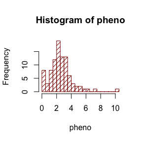

```r
hist(pheno, breaks = 30, density = 15, col = "darkred")
```

The command:

```r
table(chr)
```

```
#> chr
#>    1    2    3    4    5
#> 5000 3000 4000 2000 6000
```

shows exactly the number of markers on each of the five simulated chromosomes.

Now, the objects loaded in R are ready for a vGWA scan, which can be done using the single command:

```r
vgwa <- vGWAS(phenotype = pheno, geno.matrix = geno, marker.map = map, chr.index = chr, pB = FALSE)
#vgwa <- vGWAS(phenotype = pheno, geno.matrix = geno, marker.map = map, chr.index = chr, pB = TRUE)
```

A progress bar will indicate the progress of the scan if pB is set to TRUE.

When the scan is finished, all the output statistics will be returned as a list into the object vgwa, which belongs to the class ‘vGWAS’. Any object that has a structure belonging to class ‘vGWAS’ can be directly passed into S3 method function plot. For instance, simply run the following command, we can plot the results in vgwa:

```
#> nominal significance threshold with Bonferroni correction for 20000 tests are calculated.
```

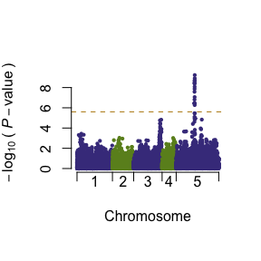

```r
plot(vgwa)
```

Regarding the marker that gave the highest score, the heritability explained by the mean and variance can be split and calculated via:

```r
vGWAS.variance(phenotype = pheno, marker.genotype = geno[,vgwa$p.value == min(vgwa$p.value)])
```

```
#> variance explained by the mean part of model:
#> 4.2 %
#> variance explained by the variance part of model:
#> 23.06 %
#> variance explained in total:
#> 27.26 %
#> $vm
#>         C
#> 0.1026317
#>
#> $vv
#>         C
#> 0.5628937
#>
#> $ve
#>       C
#> 1.77584
#>
#> $vp
#>        C
#> 2.441366
```

The output can also be stored if assigning the function call to an object.

To correct for population confounding, the package applies the method HEVA (h-likelihood-based efficient variance association), described in the reference paper of the package.

One may input pre-calculated kinship matrix, e.g. IBD or IBS matrix, and call vGWAS with heva = TRUE, kinship = calculated.kinship.

Instead, the inbuilt function vGWAS.heva automatically constructs a simple genomic kinship from the genotype data. Simply, runing:

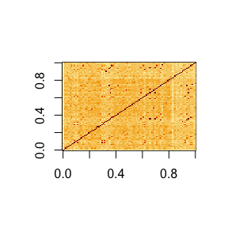

```r
geno.coding <- matrix(0, nrow(geno), ncol(geno))
#pb <- txtProgressBar(style = 3)
for (j in 1:ncol(geno)) {
       geno.coding[,j] <- as.numeric(geno[,j] == names(table(geno[,j]))[1])*2 - 1
       #setTxtProgressBar(pb, j/ncol(geno))
}
image(tcrossprod(geno.coding))
```

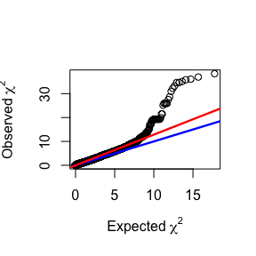

```r
#vgwa2 <- vGWAS(phenotype = pheno, geno.matrix = geno.coding, heva = TRUE, marker.map = map, chr.index = chr)
vgwa2 <- vGWAS.gc(vgwa)
```

```
#> nominal significance threshold with Bonferroni correction for 20000 tests are calculated.
```

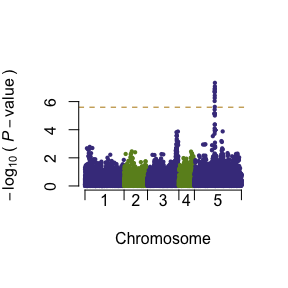

```r
plot(vgwa2)
```

## Remarks

The package source and further development information are on the R-Forge project page: https://r-forge.r-project.org/projects/vgwas/

A reimplementation of vGWAS as a devtool package can be found here: https://github.com/kullrich/vGWAS